# Lab 1 Solution

1. Download data from quandl on closing stock price of GE. (hint: GE’s ticker is GE)

```r
library(tidyverse)
ge <- read_csv("https://www.quandl.com/api/v3/datasets/WIKI/GE.csv")
```

```r
glimpse(ge)
```

```
## Observations: 14,100
## Variables: 13
## $ Date          <date> 2018-01-05, 2018-01-04, 2018-01-03, 2018-01-02,...
## $ Open          <dbl> 18.860, 18.380, 18.300, 17.580, 17.270, 17.350, ...
## $ High          <dbl> 18.87, 18.62, 18.34, 17.99, 17.53, 17.40, 17.63,...
## $ Low           <dbl> 18.5000, 18.3000, 18.0300, 17.5300, 17.2700, 17....
## $ Close         <dbl> 18.54, 18.53, 18.15, 17.98, 17.45, 17.36, 17.38,...
## $ Volume        <dbl> 79151826, 81712858, 81279827, 77244095, 75906686...
## $ `Ex-Dividend` <dbl> 0, 0, 0, 0, 0, 0, 0, 0, 0, 0, 0, 0, 0, 0, 0, 0, ...
## $ `Split Ratio` <dbl> 1, 1, 1, 1, 1, 1, 1, 1, 1, 1, 1, 1, 1, 1, 1, 1, ...
## $ `Adj. Open`   <dbl> 18.860, 18.380, 18.300, 17.580, 17.270, 17.350, ...
## $ `Adj. High`   <dbl> 18.87, 18.62, 18.34, 17.99, 17.53, 17.40, 17.63,...
## $ `Adj. Low`    <dbl> 18.5000, 18.3000, 18.0300, 17.5300, 17.2700, 17....
## $ `Adj. Close`  <dbl> 18.54, 18.53, 18.15, 17.98, 17.45, 17.36, 17.38,...
## $ `Adj. Volume` <dbl> 79151826, 81712858, 81279827, 77244095, 75906686...
```

There are 14100 observations. (Note that his may be different depending on when you downloaded the data.)

3. Rename Adj. Close as `ge`.

```r
ge <- rename(ge, ge=`Adj. Close`)
```

4. Plot the closing prices of GE’s stock over time. Use [this documentation for ggplot2](http://rstudio-pubs-static.s3.amazonaws.com/3364_d1a578f521174152b46b19d0c83cbe7e.html) to add title to your plot.

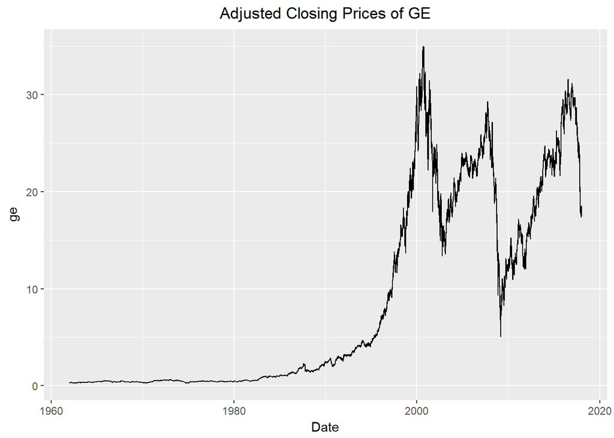

```r
ggplot(ge, aes(x=Date, y=ge)) + geom_line() +
  labs(title="Adjusted Closing Prices of GE") +
  theme(plot.title = element_text(hjust = 0.5))
```

5. Use [the same documentation](http://rstudio-pubs-static.s3.amazonaws.com/3364_d1a578f521174152b46b19d0c83cbe7e.html) to create a new plot that uses logarithmic scale on the y axis. Add pretty labels on the y axis (‘breaks’ in ggplot terminology). E.g. 100,200,400 etc.

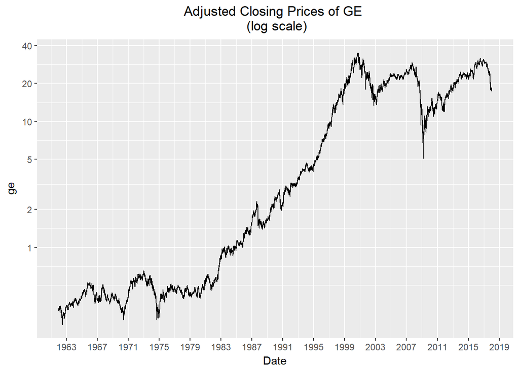

```r
ggplot(ge, aes(x=Date, y=ge)) + geom_line() +
  ggtitle("Adjusted Closing Prices of GE \n (log scale)") +
  theme(plot.title = element_text(hjust = 0.5)) +
  scale_y_continuous(trans="log", breaks=c(1,2,5,10,20,40)) +
  scale_x_date(date_breaks = "4 years", date_labels = "%Y")
```

6. Explain why we see different patterns on the linear versus logarithmic scale plots. (Hint 1: Noting that one is on a logarithmic scale and one is on a linear scale is not a sufficient answer. Hint 2: Think about what the vertical distances between points represent on each of the graphs.)

The vertical distances on the logarithmic scale graph represent *relative* changes in the GE stock price, whereas the vertical distances on the linear scale represent *absolute* changes. For example, on the logarithmic scale, the vertical distance between 1 and 2 is the same as between 10 and 20 because in relative/percent terms going from 1 to 2 is the same as going from 10 to 20. In contrast, on a linear scale, going from 10 to 20 is ten times the vertical distance (10 points) of going from 1 to 2 (1 point). Investors care about relative price change rather than absolute price change (a stock going from $1 to $2, is the same thing as a stock going from $10 to $20). Therefore, stock prices are often plotted on a log scale.

7. What are your overall conclusions from these two plots? In other words, what are the key things you feel can be learned about the behavior of the GE over this time frame?

Overall, in the last 55 years GE stock price rose substantially, but the rise is far from uniform. There are many short-term fluctuations - declines and recoveries that last a few months - but also long-term fluctuations where declines and recoveries last over a decade. It looks like GE’s stock peaked around 2001.

The graphs also afford us to see evidence of events we know from history or newspapers such as the tech buble of the late 1990s followed by the crash in the early 2000s. We also see the financial crisis of 2008/2009 followed by a remarkable recovery.